# Reproducible Research

### 1. Loading and preprocessing the data

Load the data and transform it into a format suitable for your analysis:

```r
activity <- read.csv("activity.csv", header = TRUE, sep = ",", na.strings = "NA")
activity$date <- as.Date(activity$date, format = "%Y-%m-%d")
activity$interval <- factor(activity$interval)
```

### 2. What is mean total number of steps taken per day?

1. Calculate the total number of steps taken per day:

```r
data_steps <- as.character(activity$steps)
steps_without_na <- activity[!is.na(data_steps),]
number_steps_per_day <- aggregate(steps_without_na$steps, by=list(date = steps_without_na$date), FUN=sum)
colnames(number_steps_per_day) <- c("date", "total_steps")
head(number_steps_per_day)
```

```
##         date total_steps
## 1 2012-10-02         126
## 2 2012-10-03       11352
## 3 2012-10-04       12116
## 4 2012-10-05       13294
## 5 2012-10-06       15420
## 6 2012-10-07       11015
```

2. Make a histogram of the total number of steps taken each day:

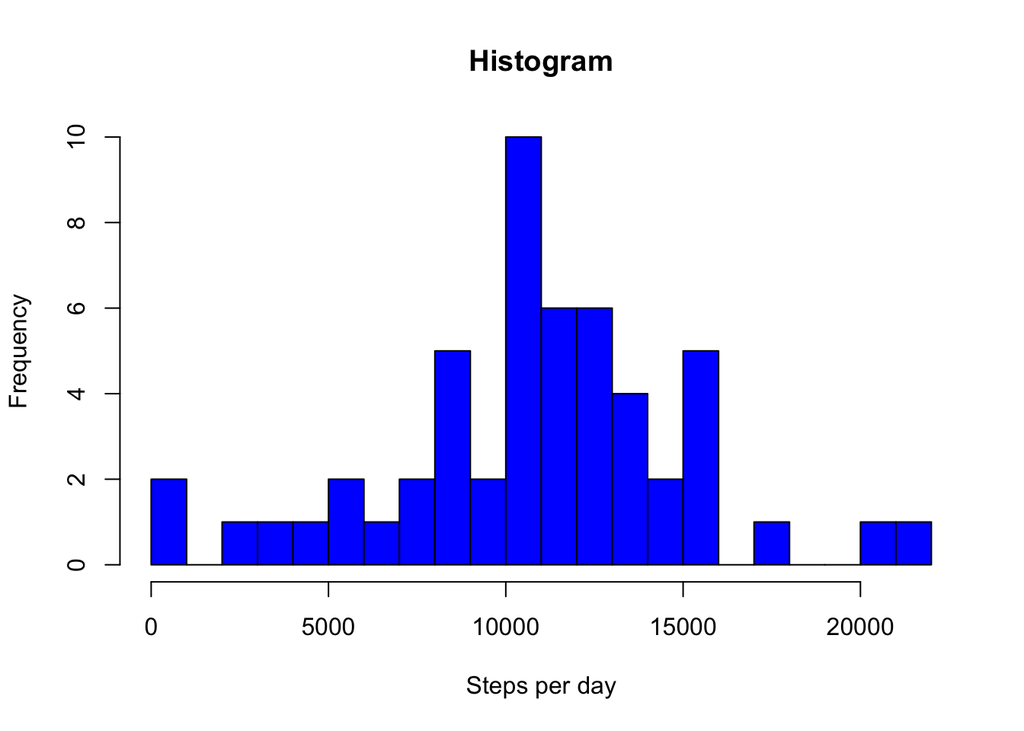

```r
hist(as.numeric(number_steps_per_day$total_steps), breaks = 30, col = "blue", xlab = "Steps per day", main= "Histogram")
```

3. Calculate and report the mean and median of the total number of steps taken per day:

```r
mean(number_steps_per_day$total_steps)
```

```
## [1] 10766.19
```

```r
median(number_steps_per_day$total_steps)
```

```
## [1] 10765
```

### 3. What is the average daily activity pattern?

1. Make a time series plot (i.e. type = “l”) of the 5-minute interval (x-axis) and the average number of steps taken, averaged across all days (y-axis)

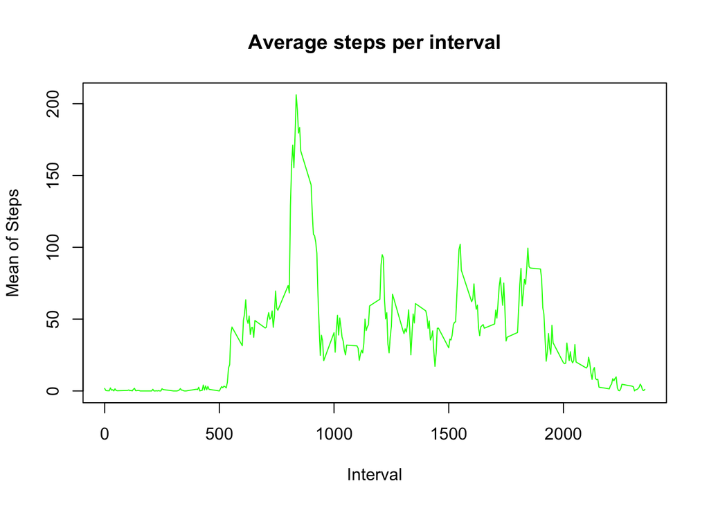

```r
mean_steps_per_interval <- aggregate(steps_without_na$steps, by=list(date = steps_without_na$interval), FUN=mean)
colnames(mean_steps_per_interval) <- c("interval", "mean_steps")
plot(as.integer(levels(mean_steps_per_interval$interval)), mean_steps_per_interval$mean_steps, type="l",
     xlab = "Interval", ylab = "Mean of Steps", main = "Average steps per interval",  col ="green")
```

```r
mean_steps <- max(mean_steps_per_interval$mean_steps)
```

```r
total_steps <- mean_steps_per_interval[which.max(mean_steps_per_interval$mean_steps),]$interval
```

### 4. Imputing missing values

1. Calculate and report the total number of missing values in the dataset (i.e. the total number of rows with NAs)

```r
sum(is.na(activity))
```

```
## [1] 2304
```

2. Devise a strategy for filling in all of the missing values in the dataset. The strategy does not need to be sophisticated. For example, you could use the mean/median for that day, or the mean for that 5-minute interval, etc.

```r
values_na_steps <- which(is.na(activity$steps))
activity[values_na_steps, ]$steps <- mean(steps_without_na$steps)
head(activity[values_na_steps, ])
```

```
##     steps       date interval
## 1 37.3826 2012-10-01        0
## 2 37.3826 2012-10-01        5
## 3 37.3826 2012-10-01       10
## 4 37.3826 2012-10-01       15
## 5 37.3826 2012-10-01       20
## 6 37.3826 2012-10-01       25
```

3. Create a new dataset that is equal to the original dataset but with the missing data filled in.

```r
summary(activity)
```

```
##      steps             date               interval
##  Min.   :  0.00   Min.   :2012-10-01   0      :   61
##  1st Qu.:  0.00   1st Qu.:2012-10-16   5      :   61
##  Median :  0.00   Median :2012-10-31   10     :   61
##  Mean   : 37.38   Mean   :2012-10-31   15     :   61
##  3rd Qu.: 37.38   3rd Qu.:2012-11-15   20     :   61
##  Max.   :806.00   Max.   :2012-11-30   25     :   61
##                                        (Other):17202
```

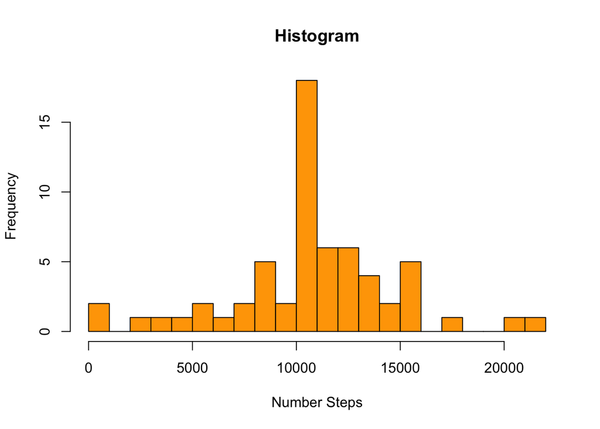

```r
number_steps_per_day <- aggregate(activity$steps, by=list(date = activity$date), FUN=sum)
colnames(number_steps_per_day) <- c("date", "total_steps")
hist(as.numeric(number_steps_per_day$total_steps), breaks = 30, col = "orange", xlab = "Number Steps", main= "Histogram")
```

```r
mean(number_steps_per_day$total_steps)
```

```
## [1] 10766.19
```

```r
median(number_steps_per_day$total_steps)
```

```
## [1] 10766.19
```

### 5. Are there differences in activity patterns between weekdays and weekends?

1. Create a new factor variable in the dataset with two levels – weekday and weekend indicating whether a given date is a weekday or weekend day.

```r
activity$day <- as.factor(weekdays(activity$date))
activity$is_weekday <- ifelse(!(activity$day %in% c("sábado","domingo")), TRUE, FALSE)
weekdays_data <- activity[activity$is_weekday,]
steps_per_interval_weekdays <- aggregate(weekdays_data$steps, by=list(interval=weekdays_data$interval), FUN=mean)
weekends_data <- activity[!activity$is_weekday,]
steps_per_interval_weekends <- aggregate(weekends_data$steps, by=list(interval=weekends_data$interval), FUN=mean)
colnames(steps_per_interval_weekdays) <- c("interval", "average_steps")
colnames(steps_per_interval_weekends) <- c("interval", "average_steps")
steps_per_interval_weekdays$day <- "Weekday"
steps_per_interval_weekends$day <- "Weekend"
week_data <- rbind(steps_per_interval_weekends, steps_per_interval_weekdays)
week_data$day <- as.factor(week_data$day)
```

2. Make a panel plot containing a time series plot (i.e. type = “l”) of the 5-minute interval (x-axis) and the average number of steps taken, averaged across all weekday days or weekend days (y-axis). See the README file in the GitHub repository to see an example of what this plot should look like using simulated data.

```r
library(lattice)
```

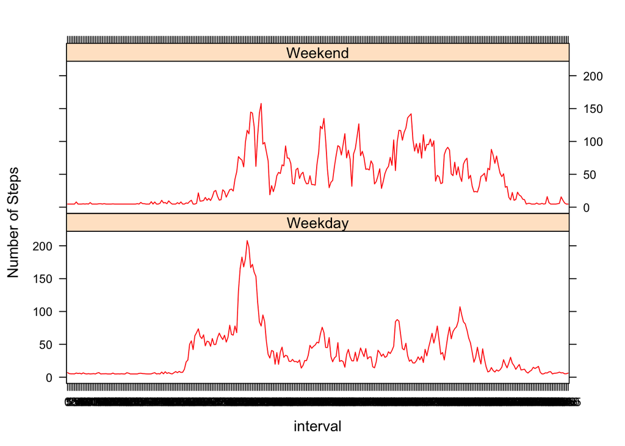

```r
xyplot(average_steps ~  interval | day, data = week_data, layout = c(1,2), type ="l", ylab="Number of Steps", col = "red")
```